# Vrije opdracht

2026-04-27

```r
# Importeren van PNG bestanden
library(png)
library(grid)
library(gridExtra)
```

# 1. conda installeren

Dit onderdeel hoeft alleen uitgevoerd te worden indien het conda installatie script nog niet is geïnstalleerd in Rstudio. Indien conda al is geïnstalleerd: begin bij stap 2.

```bash
# Download het conda installatie script
wget https://repo.anaconda.com/miniconda/Miniconda3-latest-Linux-x86_64.sh

# Run het conda installatie script
bash Miniconda3-latest-Linux-x86_64.sh -b

# Belangrijk: Na installatie, sluit de terminal en open vervolgens een nieuwe terminal (menubalk -> tools -> terminal). Dit is nodig om (mini)conda te initieren
```

# 2. conda environment opzetten

Maak een nieuwe conda environment met samtools en NanoPlot erin. Deze packages worden in de volgende stappen gebruikt.

```bash
# Aanmaken van een environment
conda create -n nanopore_clean

# Activeer de environment
conda activate nanopore_clean

# Installeren van de packages samtools en NanoPlot
conda create -n nanopore_clean -c conda-forge -c bioconda \
samtools nanoplot
```

De Python versie in de environment was 3.13.13. De versies van de gebruikte packages waren als volgt:  
-samtools 1.23.1  
-NanoPlot 1.46.2

# 3 .bam -> .fastq

De output van de nanopore sequencing werd aangeleverd als een .bam bestand. Het originele output bestand van de sequencing is terug te vinden in de gedeelde Rstudio server van daur1 via de volgende pathway: /home/data/projecticum/nanopore/paradontitis/16S114_exp1_VL5B06_11122025  
Met behulp van samtools werd het .bam bestand omgezet naar een fastq bestand.  
Belangrijk: Vaak worden output bestanden als fastq aangeleverd. Indien dit het geval is, kan stap 3 worden overgeslagen.

```bash
samtools fastq "~/parodontitis16s/raw_data/16S_exp1_11122025.bam" > "~/parodontitis16s/data/16S_exp1_11122025_filtered.fastq"
```

Belangrijk: Demultiplexing werd in het oorspronkelijke project uitgevoerd met MinKNOW op een krachtigere rekenomgeving. Voor deze heranalyse was deze stap niet reproduceerbaar, omdat alleen het bam bestand beschikbaar was zonder ruwe barcode-informatie. De demultiplexing werd oorspronkelijk waarschijnlijk op het FAST5 bestand uitgevoerd en dit bestand is alleen beschikbaar op de laptop waarop de nanopore sequencing was uitgevoerd. Daarom is ervoor gekozen om de rest van de analyse op alle samples uit te voeren. Dit betekent wel dat de data voor de parodontitis samples en de samples van de gezonde personen niet van elkaar gescheiden zijn.

# 4. analyse met NanoPlot

NanoPlot is een quality control tool voor Nanopore sequencing data die statistieken en visualisaties genereert over readlengte, kwaliteit en sequencing output.  
Eerst werd de NanoPlot analyse uitgevoerd zonder de data te filteren.

```bash
# Voer een NanoPlot analyse uit zonder de reads te filteren
NanoPlot \
--fastq ~/parodontitis16s/data/16S_exp1_11122025_filtered.fastq \
--outdir ~/parodontitis16s/nanoplot_output \
--threads 6
```

Hieronder staat een samenvatting van de statistieken van de NanoPlot analyse.  
General summary:  
Mean read length: 1,612.0  
Mean read quality: 11.8  
Median read length: 1,597.0  
Median read quality: 14.2  
Number of reads: 5,582,411.0  
Read length N50: 1,600.0  
STDEV read length: 1,054.3  
Total bases: 8,998,837,569.0  
Number, percentage and megabases of reads above quality cutoffs  
>Q10: 4778884 (85.6%) 7677.8Mb  
>Q15: 1975244 (35.4%) 3176.4Mb  
>Q20: 1611 (0.0%) 2.2Mb  
>Q25: 13 (0.0%) 0.0Mb  
>Q30: 3 (0.0%) 0.0Mb

In figuur 1 is de lengte van de reads uitgezet tegen de kwaliteit van deze reads bij de ongefilterde data.

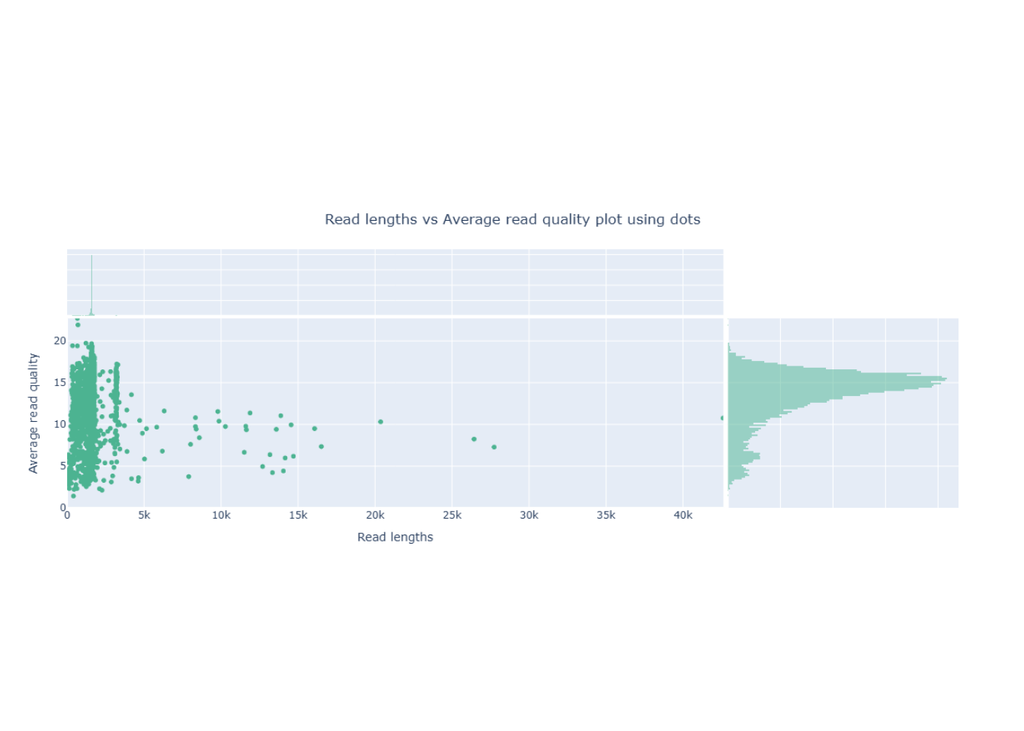

Figure 1: Lengte van de nanopore sequencing reads uitgezet tegen de kwaliteit van de reads van de ongefilterde data.

# 5. Reads filteren

Om verdere analyse op de data te doen, moeten de reads gefilterd worden.  
Voor het project werd de data gefilterd op een kwaliteitsscore van >Q10 en een lengte van 1200 tot 2000 bp. Bij nanopore sequencing is de error rate hoger dan bij illuma, daarom is gefilterd op >Q10 in plaats van >Q30, dit betekent dat de kans dat de reads kloppen 90% is. Er was op een lengte van 1200 tot 2000 bp gefilterd omdat verwacht werd dat de 16s regio’s van de meeste bacteriën ongeveer tussen de 1400 bp en 1600 bp zou zijn, maar bekend was dat sommige bacteriesoorten een kortere of langere 16s regio konden hebben.  
Om de reproduceerbaarheid te controleren, is ervoor gekozen om de data deze keer op dezelfde manier te filteren.

```bash
# Voer een NanoPlot analyse uit waarbij de reads worden gefilterd op >Q10 en een lengte van 1200 tot 2000 bp
NanoPlot \
--fastq ~/parodontitis16s/data/16S_exp1_11122025.fastq \
--minqual 10 \
--minlength 1200 \
--maxlength 2000 \
--outdir ~/parodontitis16s/analyses/filtered \
--threads 6
```

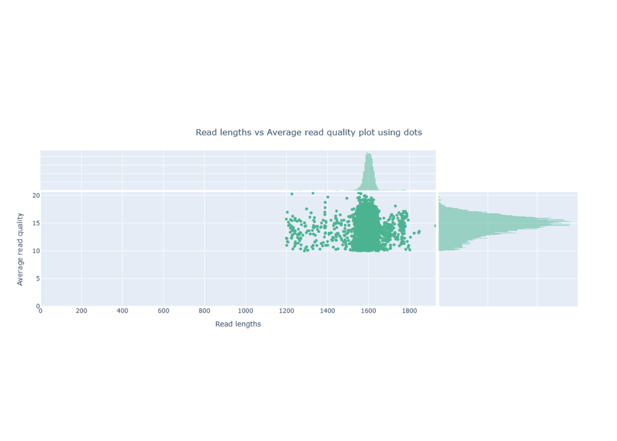

[figure not shown]